# DATA100 Introduction to Data Analytics

Lecture 9: Words and Numbers

Agassi Iu

Wilfrid Laurier University

2026-10-22

# The problem for today

## My sleep report

I want a summary of the sleep survey on:

1. How much do students in each program sleep? (*Numbers*, Chapter 13)
2. When do they go to bed? (*Strings*, Chapter 14)
3. Can we make the chart readable? (*Factors*, Chapter 16)

## What the chart looks like without any work

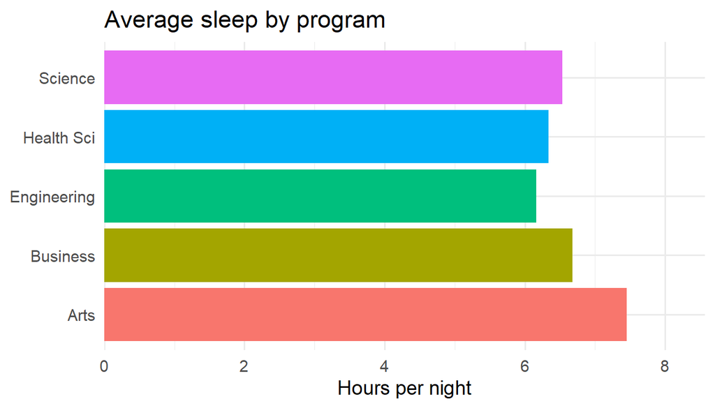

## Foreshadowing the final output of today

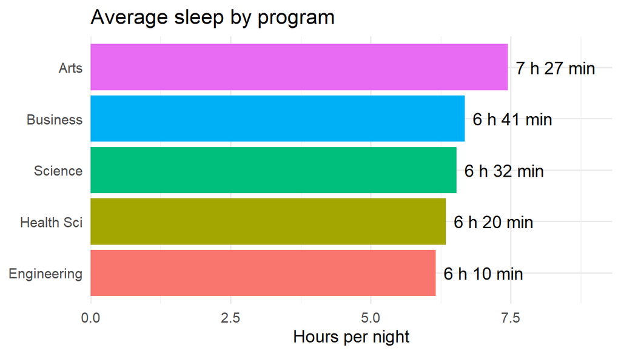

## Setup and data

The data is the same sleep survey from Lecture 8. It is loaded once at the start:

```r
library(dplyr); library(tidyr); library(tibble); library(readr)
library(ggplot2); library(stringr); library(forcats)

survey <- read_csv("data/sleep_survey_v2.csv", show_col_types = FALSE)
```

**Not everything fits in this 80-minute lecture**

I may leave some of the undiscussed functions or tools in an *appendix table* at the end of the slide deck. Each row will say what the tool does and which section of the chapter to read. You should definitely take a look at the text for more details.

# Part 1: Numbers

## Learning Objectives

| Step | Tool (Chapter 13) |
| --- | --- |
| Fix numbers typed as text | `parse_number()` |
| Count students | `count()`, `n()` |
| Transform columns | `pmin()`, `pmax()`, `%/%`, `%%`, `round()`, `cut()` |
| Rank programs | `min_rank()` |
| Summarize | `mean()`, `median()` |

## Making numbers:

**`parse_number()`**

Numbers sometimes arrive as text, typically when data is imported. *readr* has two parsers: - `parse_double()` for strings that are clean numbers - `parse_number()` for strings with extra text around the number

**Checkpoint**

Do you see what these functions are trying to do?

## Counting

**`count()`**

This function gives a quick tally of how many rows have each value. Add `sort = TRUE` to see the biggest groups first.

**n() only works inside dplyr verbs**

`n()` returns the size of the current group. Outside of `summarize()`, `mutate()`, or `filter()`, there is no “current group”, so it fails. - i.e. `survey |> n(program)` doesn’t mean anything.

## Recycling Vectors

When two vectors have different lengths, *R* recycles the shorter one by repeating it. That can quietly give wrong answers. Are the students in Arts or Business?

**Doesn’t give you an error, just the wrong answer**

*R* compares `program` with `"Arts", "Business", "Arts", "Business", ...` row by row. It does **not** ask “is the program Arts or Business?”. You only get about half of the students.

## A simpler example

**Live Exercise**

Run the following code to test how *R* recycles vectors of values

## Maximum and Minimum

- `pmin()` and `pmax()` work **row by row** across vectors (the “p” is for parallel)
- `min()` and `max()` summarize **everything** into one value

**Key idea**

Every row gets the **same** answer from `min()` and `max()`: the smallest and largest value in both columns combined. Use `pmin()` and `pmax()` for a per-row answer.

## Time: Hours and minutes

**Modular Arithmetic**

Division with a quotient and a remainder: - `%/%` is integer division - `%%` is the remainder - E.g. `7%/%3=2` and `7%%3=1`.

`sleep_hours = 6.7` means 6 hours and 42 minutes. Modular arithmetic splits it:

## Rounding

**`round(x)`**

This function rounds to the nearest integer. You can even add a `digits` argument that controls where to round, and this value `digits` can be negative!

**Always round down or up?**

`floor()` always rounds down and `ceiling()` always rounds up. See the appendix.

## Cutting numbers into ranges

**`cut()`**

This function chops a numeric vector into *bins* and returns a factor. You supply the break points. Give `labels` one *fewer* element than `breaks`.

**Open-ended bins**

- Values **outside** the breaks become `NA`. Use `-Inf` and `Inf` as the outer breaks so nothing falls off the ends.
- Bins are right-closed by default, like `(5, 10]`. Pass `right = FALSE` to make them left-closed, like `[5, 10)`.

## Ranking

**`min_rank()`**

This function gives the rank of each value. `1` is the smallest, unless you flip it with `desc()`.

- Which program sleeps the least?

## Summaries: mean or median?

**Perhaps an explanation**

Many students do not work at all, which drags the median down while a few heavy workers pull the mean up. When a distribution is **skewed**, maybe it’s worth it to report both mean and median.

## Back to answering the question

## Exercise 1

**Live exercise**

Use `cut()` to make a `study_band` column from `study_hours_week`: under 10, 10 to 19, 20 to 29, and 30 or more. Count the students in each band.

# Part 2: Strings (Words)

## Learning Objectives

| Step | Tool (Chapter 14) |
| --- | --- |
| Build text from data | `str_c()` |
| Measure text | `str_length()` |
| Split one column into several | `separate_wider_delim()` |
| Tidy up capitals | `str_to_lower()`, `str_to_upper()` |

## Combining text:

**`str_c()`**

This function takes any number of vectors and returns a character vector. It is similar to base *R*’s `paste0()`, but it follows tidyverse recycling rules.

**Missing values are contagious**

## Oh wait! What’s the problem?

**Checkpoint with `bedtime`**

Click `Run Code` and view the `bedtime` variable from the first 15 responses. And then look at the counts of different types of responses collected from the students. Can I get any meaningful results from this table?

- `11:30 PM`, `11:30 pm`, `11.30 pm`, `23:30`, `2330`…
- Some entries are not even times at all
- We need to clean this column before we can use it

## Length of a string

**`str_length()`**

This function counts the characters in each string. A missing value gives `NA`.

- Long entries are usually hedged answers (`around ...`) or words instead of times

## Splitting into columns

**`separate_wider_delim()`**

A time like `"11:30 pm"` has two pieces separated by a space. This function splits a column on a delimiter, with a new column per piece. You supply *names* for the new columns.

**It refuses to guess**

`separate_wider_delim()` expects every string to split into the **same number** of pieces. Real data does not. The function **errors** rather than guessing, and the message tells you what to try.

## Debug mode

`too_few = "debug"` and `too_many = "debug"` keep the result but add diagnostic columns, named after the input column:

- `bedtime_ok`: did this row split cleanly?
- `bedtime_pieces`: how many pieces it had
- `bedtime_remainder`: any leftover text
- **Too few** pieces: `11:30PM`, `2330`, `midnight`
- **Too many** pieces: `around 11 pm`, `no set time`, and entries with a stray space at the start

## Fixing it

- `str_trim()` removes stray spaces at the start and end
- `str_to_lower()` makes `PM`, `Pm` and `pm` the same
- `too_few = "align_start"` fills missing pieces with `NA` at the end
- `too_many = "merge"` glues the extra pieces onto the last column

## Putting the pieces together

- Rows we cannot trust remain as `NA`

## How far did we get?

| Problem | Solved today? |
| --- | --- |
| Capital letters (`PM`, `Pm`, `pm`) | Yes: `str_to_lower()` |
| Stray spaces | Yes: `str_trim()` |
| `11:30 pm` becomes `11:30 PM` | Yes: `separate_wider_delim()` and `str_c()` |
| Glued times (`11:30pm`, `12:00AM`) | **No** |
| Different separators and missing minutes (`11.30 pm`, `11 pm`) | **Partly**: they split, but are not in one format |
| Hedged answers (`around 11`, `~11:30 pm`) | **No** |
| 24-hour (`23:30`, `2330`) and no AM/PM (`11:30`) | **No** |
| `midnight`, `idk`, blank | **No** |

## Foreshadowing

**Next week**

We need a way to describe a **pattern** instead of an exact string. That is what regular expressions do (Chapter 15). Roughly 4 in 10 bedtimes are still unreadable after today.

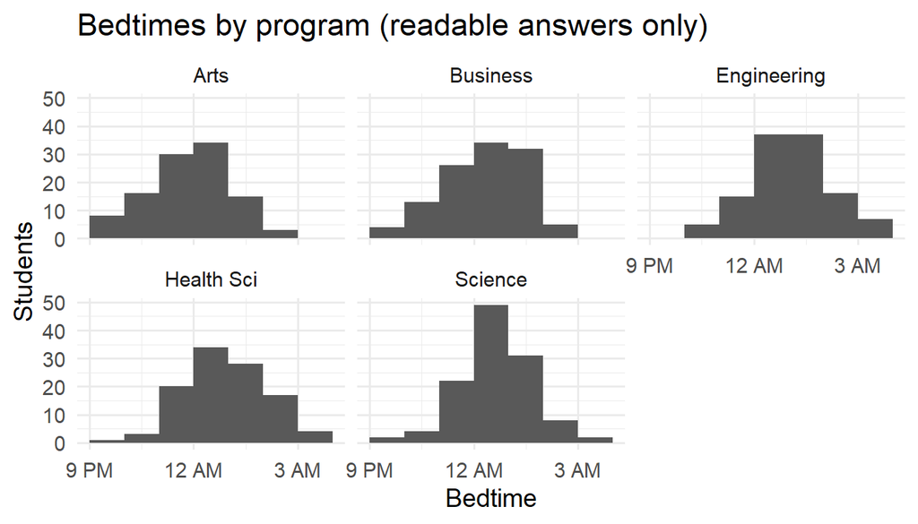

## Exercise 2

**Live exercise**

1. How many students typed a `bedtime` longer than 10 characters? What do those entries look like?
2. Use `str_c()` to make a label for each student, like `S499733 (Arts): 11:30 PM`. What happens to students with a blank bedtime?

# Part 3: Factors

## Can we make the chart readable?

- Programs are in **alphabetical** order, which tells me nothing

**Definition**

A *factor* is how R stores a categorical variable that has a fixed set of possible values, which is called *levels*. *Factors* let you choose the order.

## Creating a factor

**`factor()`**

**Silent NA**

Any value that is **not** in `levels` silently becomes `NA`. There is no warning. Always check the result.

## Reordering levels

**`fct_reorder()`**

This function `fct_reorder(f, x)` orders the levels of `f` by the values in `x`. It is perfect for plots.

- The program that sleeps the least is at the bottom, the most at the top

## Reordering by hand

**`fct_relevel()`**

The “sleep groups” from Lecture 8 are *text*, so a plot puts them in alphabetical order. `fct_relevel()` lets you list the levels in the order you want.

## Renaming levels

**`fct_recode()`**

This function can be used to rename a *level*. The syntax is `new name = "old name"`. Also, *levels* you do not mention stay the same.

## Merging levels

**`fct_collapse()`**

**A lookup table is better**

Typing groupings by hand is fine for five drinks. With many levels, you would use a lookup table with the caffeine amounts instead. That is a **join**, in Lecture 11.

## The finished chart

- **Numbers** gave us the averages, the hours and minutes
- **Strings** gave us the label
- **Factors** gave us the order

## Exercise 3

**Live exercise**

For students who answered the favourite drink question:

1. Count the students for each drink, then draw a sideways column chart with the drinks ordered from the most common to the least common, using `fct_reorder()`.
2. Use `fct_collapse()` to group the drinks into `"Hot"` (Coffee, Tea) and `"Cold"` (Energy drink, Pop, Water). Count the students in each group.

# Wrap-up

## Back to the report

| Question | Chapter | Tools we used |
| --- | --- | --- |
| How much do they sleep? | **Numbers** | `count()`, `%/%`, `%%`, `round()`, `cut()`, `min_rank()`, `median()` |
| When do they go to bed? | **Strings** | `str_c()`, `str_length()`, `separate_wider_delim()`, `str_to_lower()` |
| Is the chart readable? | **Factors** | `fct_reorder()`, `fct_relevel()`, `fct_recode()`, `fct_collapse()` |

## What’s next, and sources

**Lecture 10: Fancy words and numbers**

- **Regular expressions**: finish cleaning `bedtime`
- **Dates and times**: turn those clean times into real date-times

**Attribution**

Content adapted from *R for Data Science (2e)* by Hadley Wickham, Mine Çetinkaya-Rundel, and Garrett Grolemund:

- Chapter 13: Numbers, https://r4ds.hadley.nz/numbers.html
- Chapter 14: Strings, https://r4ds.hadley.nz/strings.html
- Chapter 16: Factors, https://r4ds.hadley.nz/factors.html

# Appendix: read the text

## Numbers: other tools (i)

| Tool | What it does | Tiny example | Read the section on |
| --- | --- | --- | --- |
| `count(..., wt = )` | A weighted count: a sum of another column | `count(program, wt = study_hours_week)` | Counts |
| `sum(is.na(x))` | Counts the missing values | `sum(is.na(sleep_hours))` | Counts |
| `n_distinct()` | Counts the unique values. Does every student appear once? `NA` counts as a value unless `na.rm = TRUE` | `n_distinct(student_id)` | Counts |
| `floor()`, `ceiling()` | Round down / up. No `digits` argument, so scale first | `floor(123.456)` | Rounding |

## Numbers: other tools (ii)

| Tool | What it does | Tiny example | Read the section on |
| --- | --- | --- | --- |
| `sd()`, `IQR()` | Spread: standard deviation, and the width of the middle half | `sd(sleep_hours, na.rm = TRUE)` | Spread |
| `quantile()` | Any percentile of a vector | `quantile(x, 0.9)` | Minimum, maximum, and quantiles |
| `log()`, `log2()`, `log10()` | Logarithms. Each +1 on `log2()` means the value **doubled** | `log2(c(1, 2, 4, 8))` | Logarithms |

## Numbers: other tools (iii)

| Tool | What it does | Tiny example | Read the section on |
| --- | --- | --- | --- |
| `cumsum()`, `cummean()`, … | Running totals, means, minimums, maximums | `cumsum(1:10)` | Cumulative aggregates |
| `lag()`, `lead()` | The previous / next value, for comparing neighbours | `x - lag(x)` | Offsets |
| `consecutive_id()` | Starts a new id every time a value changes | `consecutive_id(c(1, 1, 2, 2, 1))` | Consecutive identifiers |

## Numbers: other tools (iv)

| Tool | What it does | Tiny example | Read the section on |
| --- | --- | --- | --- |
| `dense_rank()`, `row_number()`, `percent_rank()` | Other ways to rank, with different tie handling | `row_number(x)` | Ranks |
| `first()`, `last()`, `nth()` | Pick a value by position | `first(x)` | Positions |
| `cut_interval()`, `cut_number()`, `cut_width()` | ggplot2 helpers for common binning patterns | `cut_width(x, 10)` | Cutting numbers into ranges |

## Strings: other tools (i)

| Tool | What it does | Tiny example | Read the section on |
| --- | --- | --- | --- |
| `str_flatten()` | Collapses a vector into **one** string, so it works in `summarize()` | `str_flatten(c("x", "y"), ", ", last = ", and ")` | `str_flatten()` |
| `str_sub()` | Extracts part of a string. Negative positions count from the end | `str_sub("Apple", -3, -1)` | Subsetting strings |
| Escapes: `\"`, `\\` | Put a quote or backslash **inside** a string | `"He said \"hi\""` | Escapes |

## Strings: other tools (ii)

| Tool | What it does | Tiny example | Read the section on |
| --- | --- | --- | --- |
| Raw strings: `r"(...)"` | Write a string without escaping anything | `r"(C:\data)"` | Raw strings |
| `\n`, `\t`, `\u00b5` | New line, tab, and other special characters | `"a\tb"` | Other special characters |
| `str_view()` | Shows the **raw** contents of a string, without the escapes | `str_view("a\\b")` | Escapes |

## Strings: other tools (iii)

| Tool | What it does | Tiny example | Read the section on |
| --- | --- | --- | --- |
| `separate_wider_delim()` with `NA` names | Skips a piece | `names = c("code", NA, "year")` | Separating into columns |
| `separate_longer_delim()`, `separate_longer_position()` | Split into **rows** instead of columns | `separate_longer_delim(x, ",")` | Separating into rows |
| `separate_wider_position()` | Split fixed-width text into columns | `widths = c(year = 4, age = 2)` | Separating into columns |

## Strings: other tools (iv)

| Tool | What it does | Tiny example | Read the section on |
| --- | --- | --- | --- |
| `too_few` / `too_many` options | `"drop"`, `"merge"`, `"align_start"`, `"align_end"` | `too_many = "drop"` | Diagnosing widening problems |
| `str_to_title()` | Changes capitals | `str_to_title("jane doe")` | Non-English text |
| Encodings and locales | Non-English letters; sorting depends on the language | `str_sort(x, locale = "es")` | Non-English text |

**str_sub() and bedtime**

`str_sub(bedtime, -2, -1)` pulls out the last two characters, which is `am` or `pm` for many entries.

## Factors: other tools (i)

| Tool | What it does | Tiny example | Read the section on |
| --- | --- | --- | --- |
| `levels()` | Lists the levels of a factor | `levels(y1)` | Factor basics |
| `fct_infreq()` | Orders levels by how common they are | `fct_infreq(favourite_drink)` | Modifying factor order |
| `fct_rev()` | Reverses the order of the levels | `fct_rev(f)` | Modifying factor order |
| `fct_reorder2()` | Orders levels so a line plot’s legend matches the line ends | `fct_reorder2(f, x, y)` | Modifying factor order |

## Factors: other tools (ii)

| Tool | What it does | Tiny example | Read the section on |
| --- | --- | --- | --- |
| `fct_lump_n()`, `fct_lump_min()`, `fct_lump_prop()` | Combine the rare levels into `"Other"` | `fct_lump_n(f, n = 3)` | Modifying factor levels |
| `ordered()` | A factor whose levels have a natural order (low < medium < high) | `ordered(x, levels = ...)` | Ordered factors |
| `gss_cat` | The book’s example data: the General Social Survey | `forcats::gss_cat` | Introduction to factors |

**Try the book’s data**

Chapter 16 uses `gss_cat` throughout. It is a good place to practise `fct_reorder()` on a bigger data set.